# Exploratory Data Analysis of English Premier League Data

Curtis Burkhalter

July 13, 2018

# Quick look at the data

We will begin by first looking at a sample of data used for this project. Specifically, this dataset consists of data on goals scored in the last 10 seasons in the English Premier League. This data was obtained from http://www.footstats.co.uk.

```r
head(combined_goals)
```

```
# # A tibble: 6 x 9
#   Position Team       Played FTotal `FPer Game` ATotal `APer Game` Profile
#      <int> <chr>       <int>  <int>       <dbl>  <int>       <dbl>   <dbl>
# 1        1 Man City       38    106        2.79     27       0.710    393.
# 2        2 Man United     38     68        1.79     28       0.740    243.
# 3        3 Tottenham      38     74        1.95     36       0.950    206.
# 4        4 Liverpool      38     84        2.21     38       1.00     221.
# 5        5 Chelsea        38     62        1.63     38       1.00     163.
# 6        6 Arsenal        38     74        1.95     51       1.34     145.
# # ... with 1 more variable: seasons_rep <chr>
```

Now let’s take a look at all of the teams in the dataset and the number of seasons they have been in the Premier League for the last 10 years.

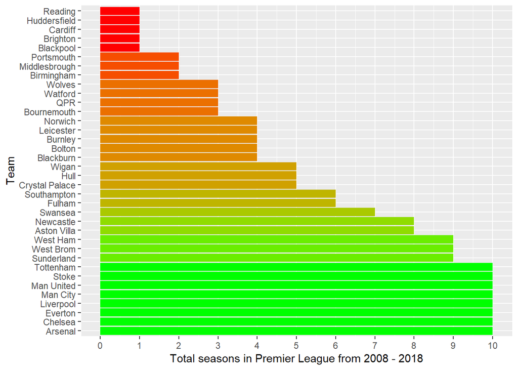

Lets look at the range of goals scored for each team across all seasons, as well as the the goals scored against each team:

```r
#range of Goals For and range of Goals against
rng_For <- range(combined_goals$FTotal)
rng_Against <- range(combined_goals$ATotal)
rng_For
```

```
# [1]  27 106
```

```r
rng_Against
```

```
# [1] 24 85
```

## Data breakouts

From here we can breakdown the results a bit further by looking at the goal distribution across seasons.

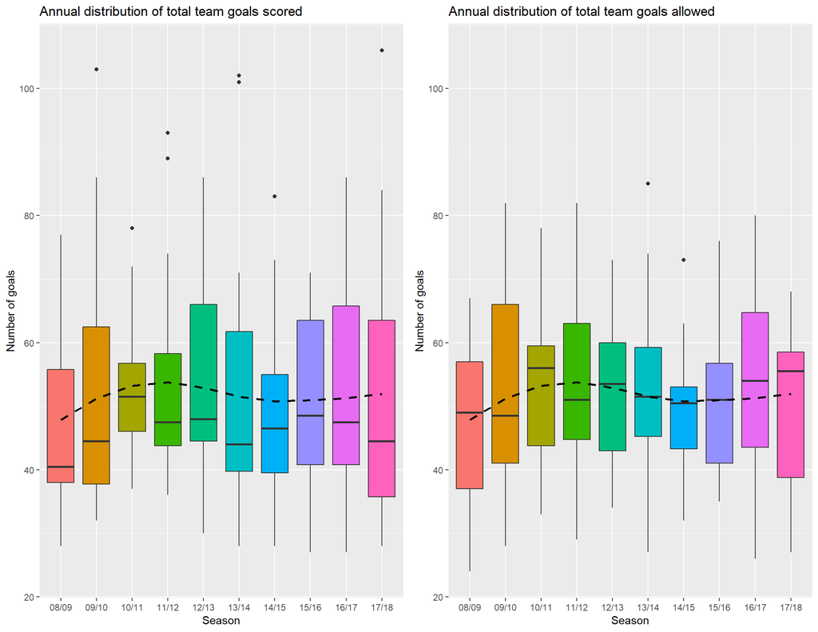

### Do we see changes in goals for different groups?

An interesting aspect to the English Premier League is the process of promotion and relegation. The bottom 3 teams for each season are relegated to the 2nd tier division of English soccer, i.e. English Championship. Additionally, the top 6 teams for each season qualify for different tournaments that take place both within English soccer, i.e. Europa League, and across Europe, i.e. Champions’ League.

A natural question is to then ask do we see changes in these groups of teams?

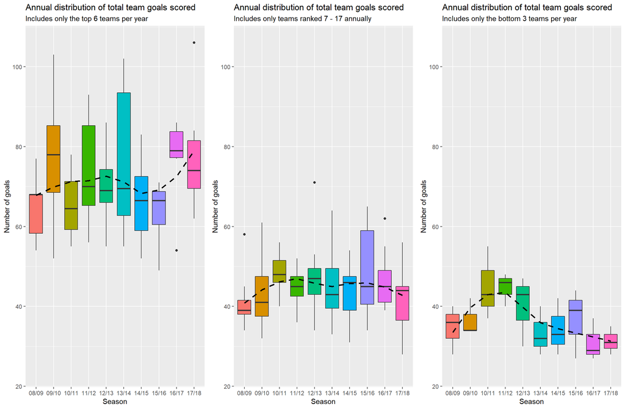